# Course project 1 (of 2)

manuel-at-coursera

Monday, October 20, 2014

This document has been created as the course project 1 (of 2) for the Coursera online course “Reproducible Research”: https://www.coursera.org/course/repdata

Describing the steps for downloading the data is not part of this assignment, wherefore we start directly with loading the data. However, the data is available here: https://d396qusza40orc.cloudfront.net/repdata%2Fdata%2Factivity.zip

#### Loading and preprocessing the data

We assume that the data is downloaded and unzipped and placed in the current working directory. With the following code the data can be loaded into R.

```r
data <- read.csv("activity.csv")
```

For our convinience in the later analysis, we pre-calculate the total number of steps per day. This means, for each day (as per the column data$date) we sum up the number of steps, given in the column data$steps. Afterwards, we adjust the column names.

```r
stepsPerDay <- aggregate(data$steps ~ data$date, data=data, FUN=sum)
colnames(stepsPerDay) <- c("date", "total")
```

#### What is mean total number of steps taken per day?

To start with, we have a look at the distribution of the total number of steps taken per day.

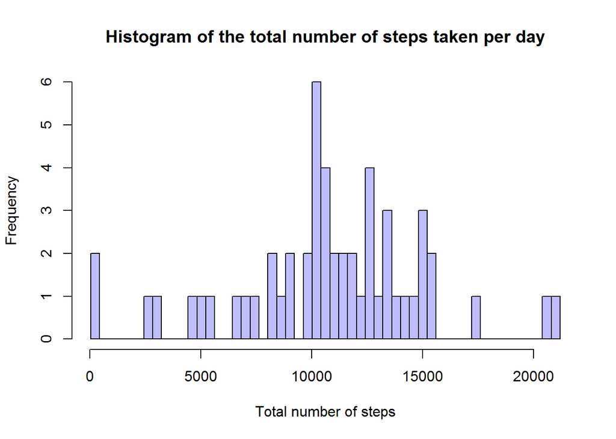

```r
with(stepsPerDay, hist(total,
                       breaks = seq(min(total), max(total), l=length(total)+1),
                       main = "Histogram of the total number of steps taken per day",
                       xlab = "Total number of steps",
                       col=rgb(0,0,1,1/4) ) )
```

For this distribution, the mean and median are as follows:

```r
print(paste("The mean value is:", mean(stepsPerDay$total)))
```

```
## [1] "The mean value is: 10766.1886792453"
```

```r
print(paste("The median is:", median(stepsPerDay$total)))
```

```
## [1] "The median is: 10765"
```

#### What is the average daily activity pattern?

As each interval represent a 5-minute-time-slot, we have in total 288 intervals for the 24 h of a day. The plot below shows in the x-axis all intervals of a day, from “0” to “2355” (which is equivalent to 23 hours and 55 minutes). The y-axis shows the average number of steps taken within each interval, based on all days in the data set. The vertical blue line marks the peak interval.

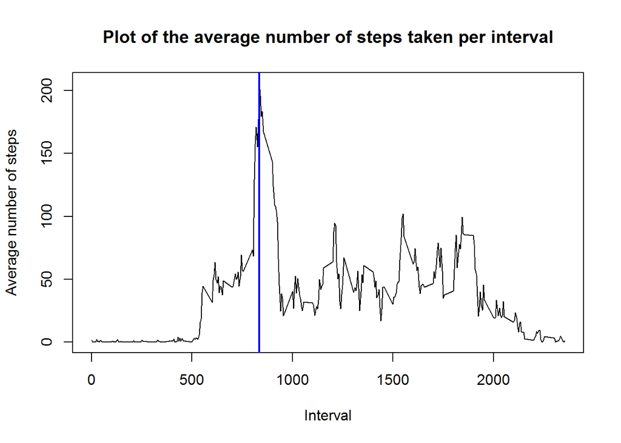

```r
averagePerInterval <- aggregate(data$steps ~ data$interval, data=data, FUN=mean)
colnames(averagePerInterval) <- c("interval", "average")
with(averagePerInterval,
     plot(interval, average, type = "l",
          main = "Plot of the average number of steps taken per interval",
          xlab = "Interval",
          ylab = "Average number of steps") )
maxInterval <- averagePerInterval[which.max(averagePerInterval$average),]
abline(v = maxInterval[,1], col = "blue", lwd = 2)
```

```r
print( paste("Interval number", maxInterval[1,1],
             "contains the hightest value, which is", maxInterval[1,2],
             "steps (on average)") )
```

```
## [1] "Interval number 835 contains the hightest value, which is 206.169811320755 steps (on average)"
```

Interval 835 corresponds to the 5 minute interval between 8:35 and 8:39 am.

#### Imputing missing values

```r
na <- sum(is.na(data$steps))
all <- length(data[,1])
p <- round(na / all * 100, digits = 2)
print( paste("In total, the data set contains",
             all,
             "observations. ",
             na,
             "of them are missing values (NA), which is a share of",
             p,
             "percent (rounded)."))
```

```
## [1] "In total, the data set contains 17568 observations.  2304 of them are missing values (NA), which is a share of 13.11 percent (rounded)."
```

The following code shows a simple approach to replace the missing values in the data set. Each NA is replaced by the mean value based on all non-missing values within the same interval (independent from the day). This replacement is done in a new data set, called “dataMeans”. Afterwards the same histogram is plotted as for the very first analysis.

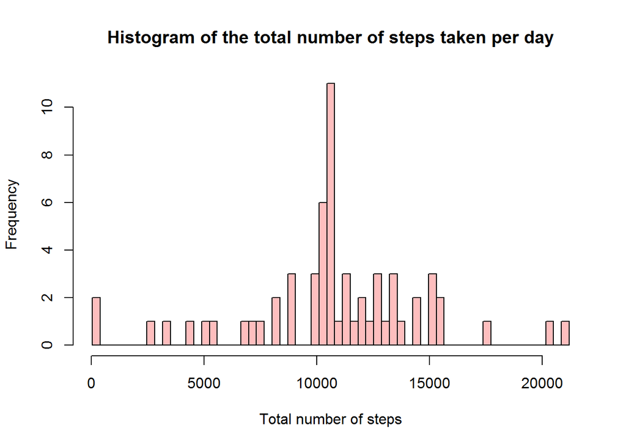

```r
dataMeans <- data
for(i in unique(data$interval)) {
    dataMeans[is.na(dataMeans$steps) & dataMeans$interval == i, 1] <- mean(data[data$interval == i, 1], na.rm = TRUE)
}
stepsPerDayMeans <- aggregate(dataMeans$steps ~ dataMeans$date, data=dataMeans, FUN=sum)
colnames(stepsPerDayMeans) <- c("date", "total")

with(stepsPerDayMeans, hist(total,
                       breaks = seq(min(total), max(total), l=length(total)+1),
                       main = "Histogram of the total number of steps taken per day",
                       xlab = "Total number of steps",
                       col=rgb(1,0,0,1/4) ) )
```

For this distribution (with NAs replaced), the mean and median are as follows:

```r
print(paste("The mean value is:", mean(stepsPerDayMeans$total)))
```

```
## [1] "The mean value is: 10766.1886792453"
```

```r
print(paste("The median is:", median(stepsPerDayMeans$total)))
```

```
## [1] "The median is: 10766.1886792453"
```

In comparison with the original distribution at the beginning the mean value has not changed at all and the median has changed only a very little bit. What has changed is the number of days, for which a total number of steps can be reported. The original histogram data contained only 53 diferent days, whereby the histogram data with replaced NAs contains 61 distinct days.

```r
print("The number of distinct days is ...")
```

```
## [1] "The number of distinct days is ..."
```

```r
print(paste("Original data:", length(stepsPerDay$date)))
```

```
## [1] "Original data: 53"
```

```r
print(paste("Data with NA replaced:", length(stepsPerDayMeans$date)))
```

```
## [1] "Data with NA replaced: 61"
```

#### Are there differences in activity patterns between weekdays and weekends?

Finally, we will check if there are different activity patterns for weekdays versus weekends. For this, we add a colum assigning the kind of day to the data set with the replaced NAs.

```r
library(timeDate)
dataMeans$days <- ("weekend")
dataMeans[isWeekday(dataMeans$date),4] <- "weekday"
dataMeans$days <- as.factor(dataMeans$days)
```

Now we split the data set, to compute the average number of steps per interval separately for weekdays / weekends. Please note, that the results of the command are hidden, as two very long lists are produced.

```r
dataByDays <- split(dataMeans, dataMeans$days)
split(dataMeans, dataMeans$days)
```

Now the two necessary data sets are aggregated.

```r
averageWeekDay <- aggregate(dataByDays[[1]]$steps ~ dataByDays[[1]]$interval, data=dataByDays[[1]], FUN=mean)
colnames(averageWeekDay) <- c("interval", "average")

averageWeekEnd <- aggregate(dataByDays[[2]]$steps ~ dataByDays[[2]]$interval, data=dataByDays[[2]], FUN=mean)
colnames(averageWeekEnd) <- c("interval", "average")
```

Finally, we can see that on weekends the activity patterns are much more diverse, compared to weekdays.

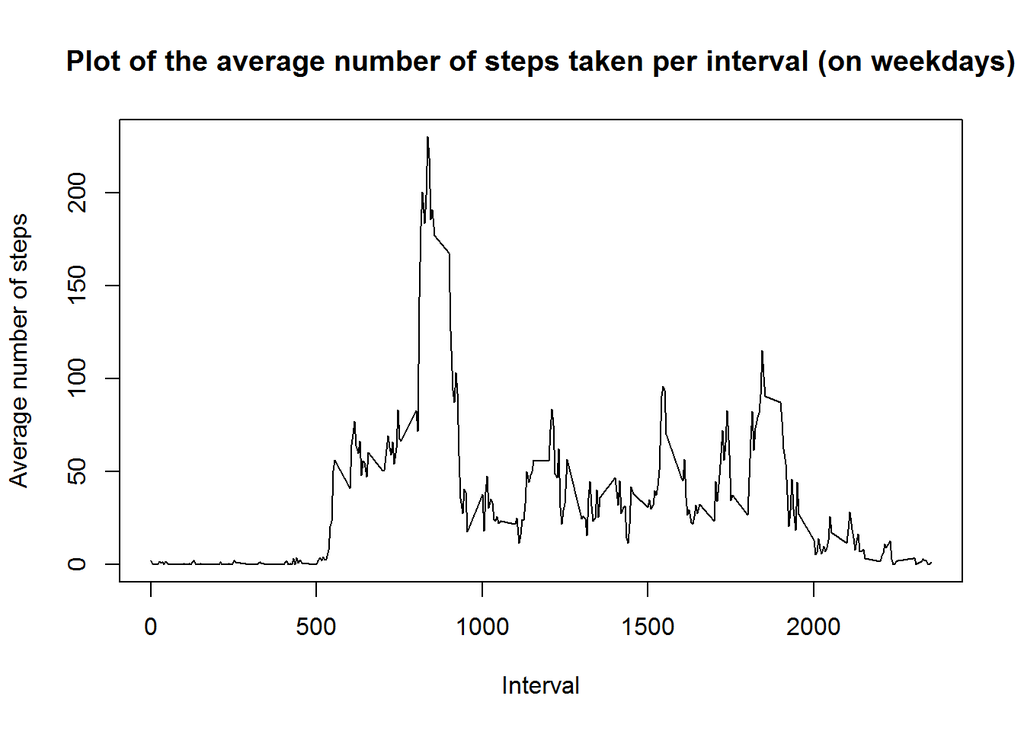

```r
with(averageWeekDay,
     plot(interval, average, type = "l",
          main = "Plot of the average number of steps taken per interval (on weekdays)",
          xlab = "Interval",
          ylab = "Average number of steps") )
```

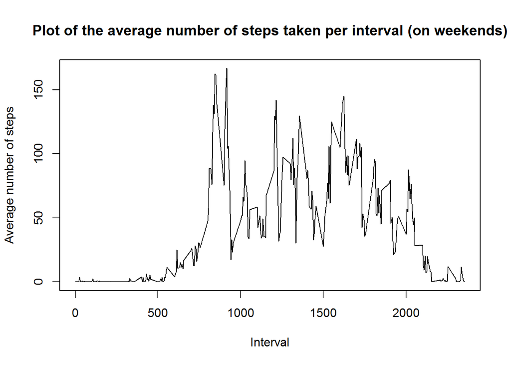

```r
with(averageWeekEnd,
     plot(interval, average, type = "l",
          main = "Plot of the average number of steps taken per interval (on weekends)",
          xlab = "Interval",
          ylab = "Average number of steps") )
```